# Chapter 3 homework

Author

Zhe Chen

Published

January 25, 2026

## Setup

```r
library(tidyverse)
library(here)
library(broom)
```

The course datasets live in your project’s `data/` folder. Use `here::here()` so file paths work regardless of where you render from.

```r
fitness <- readr::read_csv(here::here("data", "fitness.csv"))
```

## 1. Is this a “normal” group (resting pulse)?

The dataset `fitness.csv` contains (among other variables) resting pulse rate (`RSTPULSE`) for a sample of men. A commonly cited “normal” resting pulse rate for men is 72. We want to assess whether this sample looks consistent with that reference value.

### (a) Specify MODEL C, MODEL A, and the null hypothesis

Write both a verbal description and a mathematical statement.

- **MODEL C (compact):** predicts the reference value for every case
  $$\text{RSTPULSE}_i = 72 + \varepsilon_i$$
  In model C, the $RSTPULSE$ of each men is predicted as 72.
- **MODEL A (augmented):** estimates the sample mean (one-parameter model)
  $$\text{RSTPULSE}_i = b_0 + \varepsilon_i$$
  In Model A, the $RSTPULSE$ of each men is predicted as $b_0$ (mean of $RSTPULSE$).
- **Null hypothesis:** $H_0: b_0 = 72$ (equivalently, the population mean resting pulse equals 72)

### (b) Estimate both models with `lm()`

A convenient way to fit these with `lm()` is to *re-express* the outcome as a deviation from the null value.

Let $Y_i = \text{RSTPULSE}_i - 72$. Then:

- MODEL C becomes $Y_i = 0 + \varepsilon_i$ (0 parameters)
- MODEL A becomes $Y_i = b_0 + \varepsilon_i$ (1 parameter)

```r
fitness <- fitness |>
  mutate(rst_dev = RSTPULSE - 72)

model_c <- lm(rst_dev ~ 0, data = fitness)
model_a <- lm(rst_dev ~ 1, data = fitness)

summary(model_c)
```

```
Call:
lm(formula = rst_dev ~ 0, data = fitness)

Residuals:
   Min     1Q Median     3Q    Max
 -32.0  -24.0  -20.0  -13.5    4.0

No Coefficients

Residual standard error: 20 on 31 degrees of freedom
```

```r
summary(model_a)
```

```
Call:
lm(formula = rst_dev ~ 1, data = fitness)

Residuals:
    Min      1Q  Median      3Q     Max
-13.742  -5.742  -1.742   4.758  22.258

Coefficients:
            Estimate Std. Error t value Pr(>|t|)
(Intercept)   -18.26       1.49  -12.26 3.29e-13 ***
---
Signif. codes:  0 '***' 0.001 '**' 0.01 '*' 0.05 '.' 0.1 ' ' 1

Residual standard error: 8.294 on 30 degrees of freedom
```

```r
broom::tidy(model_a)
```

```
# A tibble: 1 × 5
  term        estimate std.error statistic  p.value
  <chr>          <dbl>     <dbl>     <dbl>    <dbl>
1 (Intercept)    -18.3      1.49     -12.3 3.29e-13
```

```r
broom::glance(model_a)
```

```
# A tibble: 1 × 12
  r.squared adj.r.squared sigma statistic p.value    df logLik   AIC   BIC
      <dbl>         <dbl> <dbl>     <dbl>   <dbl> <dbl>  <dbl> <dbl> <dbl>
1         0             0  8.29        NA      NA    NA  -109.  222.  225.
# ℹ 3 more variables: deviance <dbl>, df.residual <int>, nobs <int>
```

### (c) Calculate PRE

Use:

$$\text{PRE} = \frac{\text{SSE}_C - \text{SSE}_A}{\text{SSE}_C}$$

For `lm` objects, you can get SSE (a.k.a. RSS) with `deviance()`.

```r
sse_c <- deviance(model_c)
sse_a <- deviance(model_a)

pre <- (sse_c - sse_a) / sse_c
pre
```

```
[1] 0.8335267
```

### (d) Write a tentative summary

In a short paragraph, summarize what you found and what it suggests substantively. (We are not doing a formal test yet—use your judgment.)

- By moving from Model C to Model A, the sum of squared errors reduces by 83.3%, which means Model A predicts much better than Model C. Therefore, it is very likely that we should reject the null hypothesis. Given the estimate of $b_0$ in Model A is -18.3, the resting pulse rate among men in this sample is lower than the normal rate of 72.

## 2. Did running increase pulse rate?

Use the same dataset to assess whether running increased pulse rate. The variable `RUNPULSE` is post-run pulse rate.

Tip: Create a new variable that captures the *change* in pulse rate.

### (a) Specify MODEL C, MODEL A, and the null hypothesis

Let $\Delta_i = \text{RUNPULSE}_i - \text{RSTPULSE}_i$.

- **MODEL C (compact):** no average increase
  $$\Delta_i = 0 + \varepsilon_i$$

  In model C, the $\Delta$ of each men is predicted as 0.
- **MODEL A (augmented):** estimate the average increase
  $$\Delta_i = b_0 + \varepsilon_i$$

### (b) Estimate both models with `lm()`

```r
fitness <- fitness |>
  mutate(pulse_change = RUNPULSE - RSTPULSE)

model_c <- lm(pulse_change ~ 0, data = fitness)
model_a <- lm(pulse_change ~ 1, data = fitness)

summary(model_c)
```

```
Call:
lm(formula = pulse_change ~ 0, data = fitness)

Residuals:
   Min     1Q Median     3Q    Max
  92.0  111.0  116.0  123.5  136.0

No Coefficients

Residual standard error: 116.4 on 31 degrees of freedom
```

```r
summary(model_a)
```

```
Call:
lm(formula = pulse_change ~ 1, data = fitness)

Residuals:
     Min       1Q   Median       3Q      Max
-23.9032  -4.9032   0.0968   7.5968  20.0968

Coefficients:
            Estimate Std. Error t value Pr(>|t|)
(Intercept)  115.903      1.966   58.95   <2e-16 ***
---
Signif. codes:  0 '***' 0.001 '**' 0.01 '*' 0.05 '.' 0.1 ' ' 1

Residual standard error: 10.95 on 30 degrees of freedom
```

```r
broom::tidy(model_a)
```

```
# A tibble: 1 × 5
  term        estimate std.error statistic  p.value
  <chr>          <dbl>     <dbl>     <dbl>    <dbl>
1 (Intercept)     116.      1.97      59.0 1.40e-32
```

```r
broom::glance(model_a)
```

```
# A tibble: 1 × 12
  r.squared adj.r.squared sigma statistic p.value    df logLik   AIC   BIC
      <dbl>         <dbl> <dbl>     <dbl>   <dbl> <dbl>  <dbl> <dbl> <dbl>
1         0             0  10.9        NA      NA    NA  -118.  239.  242.
# ℹ 3 more variables: deviance <dbl>, df.residual <int>, nobs <int>
```

### (c) Calculate PRE

```r
sse_c <- deviance(model_c)
sse_a <- deviance(model_a)

pre <- (sse_c - sse_a) / sse_c
pre
```

```
[1] 0.9914419
```

### (d) Write a tentative summary

In a short paragraph, summarize what you found and what it suggests substantively.

- By moving from Model C to Model A, the sum of squared errors reduces by 99.1%, which means Model A predicts much better than Model C. Therefore, it is very likely that we should reject the null hypothesis. Given the estimate of $b_0$ in Model A is 115.9, the change in pulse rate is higher than 0. In other words, running increased pulse rate.

## 3. Conceptual practice: write models and hypotheses

For each prompt below:

1. Specify MODEL C, MODEL A, and the null hypothesis.
2. State the number of parameters in MODEL C and MODEL A.
3. State the number of **unused-but-potential parameters** in MODEL A (degrees of freedom), using the course definition.

Do **not** write your models generically as “$Y = \dots$”. Use the named dependent variable (e.g., “IQ”, “PTSD score”, etc.). If a prompt implies a *constructed variable*, define it.

### (a) IQ

IQ tests are designed to have mean 100 and standard deviation 15. You give 6 friends an online IQ test. Are your friends smarter than average?

- **MODEL C (compact):** predicts the IQ of my friends as 100

  $$\text{IQ}_i = 100 + \varepsilon_i$$

Number of parameters: 0

- **MODEL A (augmented):** predicts the IQ of my friends as $b_0$ (mean value)

  $$\text{IQ}_i = b_0 + \varepsilon_i$$

Number of parameters: 1

Unused-but-potential parameters (degrees of freedom): 5

- **Null hypothesis:** $H_0: b_0 \le 100$. The mean value of my friends’ IQ is less than or equal to 100, or my friends are not smarter than average.

### (b) PTSD

The army uses a PTSD test; scores above 37 indicate clinical levels of PTSD. A troop of 43 soldiers is tested at the end of deployment. Are these soldiers, on average, suffering from PTSD?

- **MODEL C (compact):** predicts the PTSD score of soldiers as 37

  $$\text{PTSD}_i = 37 + \varepsilon_i$$

Number of parameters: 0

- **MODEL A (augmented):** predicts the PTSD score of soldiers as $b_0$ (mean value)

  $$\text{PTSD}_i = b_0 + \varepsilon_i$$

Number of parameters: 1

Unused-but-potential parameters (degrees of freedom): 42

- **Null hypothesis:** $H_0: b_0 \le 37$. The mean value of the soldiers’ PTSD score is less than or equal to 37, or these soldiers are not suffering from PTSD.

### (c) Chipotle sales

Chipotle wants to know whether sales have rebounded after an E. coli scare. They have sales in 200 markets *before* the scare and *now*. They compute a difference score. Are sales depressed?

- **MODEL C (compact):** predicts the difference score as 0.

  $$\text{Score}_i = 0 + \varepsilon_i$$

Number of parameters: 0

- **MODEL A (augmented):** predicts the difference score as $b_0$ (mean value)

  $$\text{Score}_i = b_0 + \varepsilon_i$$

Number of parameters: 1

Unused-but-potential parameters (degrees of freedom): 199

- **Null hypothesis:** $H_0: b_0 \ge 0$. The mean value of the difference score is greater than or equal to 0, or the sales are not depressed.

## 4. With your own data

Please choose a variable from the 2024 General Social Survey. Remember to use `drop_na()` in your pipeline to get rid of missing data.

```r
## load gss2024 data
gss2024 <- readRDS(file = here::here("data", "gss2024.rds"))

## select satdemoc (R satisfied with way democracy works in America)
satdemoc <- gss2024 |>
  select(satdemoc) |>
  drop_na() |>
  haven::zap_labels()
glimpse(satdemoc)
```

```
Rows: 3,163
Columns: 1
$ satdemoc <dbl> 2, 1, 3, 4, 4, 3, 2, 2, 4, 2, 1, 2, 4, 3, 4, 3, 3, 3, 2, 3, 3…
```

### (a) Describe your dataset

Include enough detail that someone else can understand what you have.

- **(a.1)** What are the units of analysis and how many are there?

The units of analysis are individuals. There are 3163 individuals (the sample size n is 3163).

- **(a.2)** What is the dependent variable ($Y$)? How is it measured? What does its distribution look like? (A histogram and/or descriptives are fine.)

```r
# If you have data loaded, you can start with something like:
satdemoc |>
   summarize(
     n = n(),
     mean_y = mean(satdemoc, na.rm = TRUE),
     sd_y = sd(satdemoc, na.rm = TRUE))
```

```
# A tibble: 1 × 3
      n mean_y  sd_y
  <int>  <dbl> <dbl>
1  3163   2.69 0.837
```

The dependent variable $Y$ is satisfaction with way democracy works in America. It is measured in a four-point scale, where 1 = very satisfied, 2 = fairly satisfied, 3 = not very satisfied, 4 = not at all satisfied.

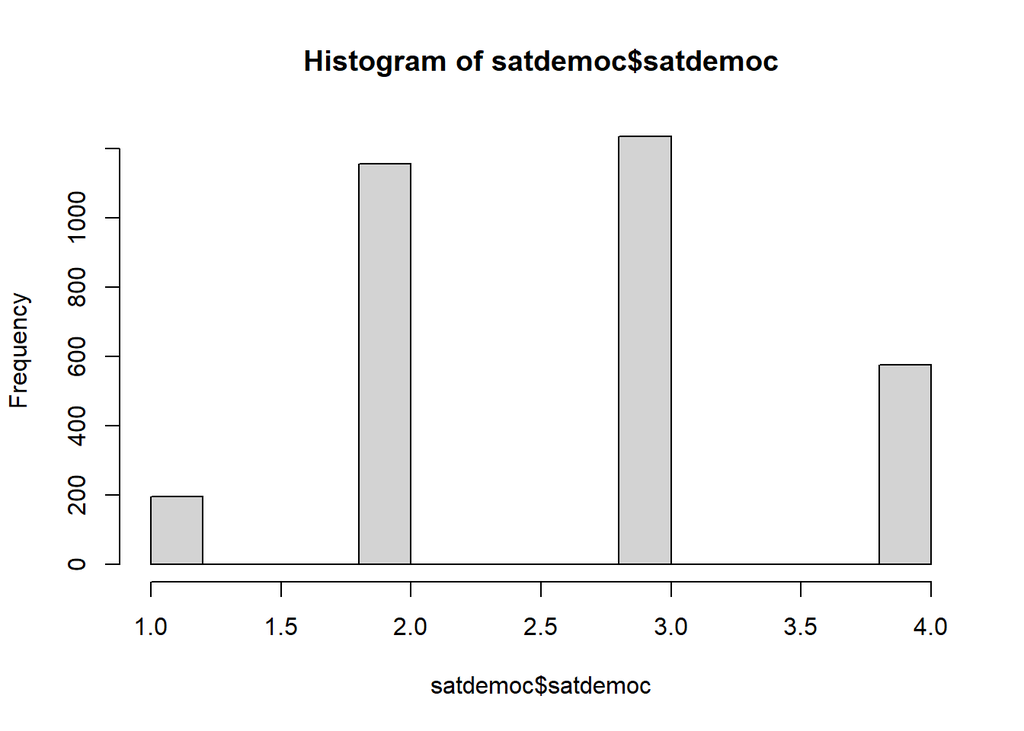

```r
hist(satdemoc$satdemoc)
```

In terms of distribution, most observations are at 2 and 3, while fewer are at 1 and 4. In other words, most people prefer mild answers over extreme expressions about their satisfaction with the way democracy works in America.

### (b) Propose a one-parameter question

Think of a question that can be tested with a MODEL C with **0 parameters** and a MODEL A that uses **1 parameter** to estimate central tendency. Write the research question in plain language.

**Research Question:** Whether American people are satisfied with the way democracy works in the United States in general?

### (c) Specify MODEL A, MODEL C, and the null hypothesis

Write both a verbal description and a mathematical statement (use $\varepsilon_i$ for error).

- **MODEL C (compact):** predicts the satisfaction score as 2.5 (neutral).

  $$\text{Satisfy}_i =2.5 + \varepsilon_i$$
- **MODEL A (augmented):** predicts the satisfaction score as $b_0$ (mean value)

  $$\text{Satisfy}_i = b_0 + \varepsilon_i$$

**Null hypothesis:** $H_0: b_0 \le 2.5$. The mean value of the satisfaction score is less than or equal to 2.5, or American people are satisfied or neutral to the way democracy works on average.

### (d) Estimate both models with `lm()`

```r
# Replace Y with your dependent variable and adapt as needed.
# If your null value is mu0, you can use the same deviation trick as in Question 1:
satdemoc <- satdemoc |>
  mutate(satdemoc_dev = satdemoc - 2.5)

sat_model_c <- lm(satdemoc_dev ~ 0, data = satdemoc)
sat_model_a <- lm(satdemoc_dev ~ 1, data = satdemoc)

summary(sat_model_c)
```

```
Call:
lm(formula = satdemoc_dev ~ 0, data = satdemoc)

Residuals:
   Min     1Q Median     3Q    Max
  -1.5   -0.5    0.5    0.5    1.5

No Coefficients

Residual standard error: 0.8592 on 3163 degrees of freedom
```

```r
summary(sat_model_a)
```

```
Call:
lm(formula = satdemoc_dev ~ 1, data = satdemoc)

Residuals:
    Min      1Q  Median      3Q     Max
-1.6927 -0.6927  0.3073  0.3073  1.3073

Coefficients:
            Estimate Std. Error t value Pr(>|t|)
(Intercept)  0.19270    0.01489   12.94   <2e-16 ***
---
Signif. codes:  0 '***' 0.001 '**' 0.01 '*' 0.05 '.' 0.1 ' ' 1

Residual standard error: 0.8374 on 3162 degrees of freedom
```

### (e) Calculate PRE

```r
sat_sse_c <- deviance(sat_model_c)
sat_sse_a <- deviance(sat_model_a)
sat_pre <- (sat_sse_c - sat_sse_a) / sat_sse_c
sat_pre
```

```
[1] 0.05030462
```

## Submission

Render this document to **PDF** and submit the PDF with your code and output.